```python
import math

import pandas as pd
import numpy as np
import matplotlib.pyplot as plt

import seaborn as sns
```

# Exploratory Data Analysis

In this report the data collected by the Twindle will be explored. This will be done by executing the following steps, based on ["A Comphrehensive Guide to Data Exploration"](https://www.analyticsvidhya.com/blog/2016/01/guide-data-exploration/) by Sunil Ray of analytics Vidhya.

1. Variable Identification
2. Univariate analysis
3. Bi-variate analysis
4. Missing value treatment
5. Outlier treatment

```python
# Load datasets
postillion_df = pd.read_csv('./data/postillion_joined.csv', parse_dates=['TimeStamp'])
big_top_df = pd.read_csv('./data/big_top_joined.csv', parse_dates=['TimeStamp'])
```

## 1. Variable Identification

Each variable can either be continuous or categorical. Both need to be analyzed in separate ways. In this chapter we are going to define these types for each variable.

```python
postillion_df.dtypes
```

```
TVOC                       float64
Pressure                   float64
CO2                        float64
Illumination               float64
Activity                   float64
TimeStamp           datetime64[ns]
TempInt                    float64
Humidity                   float64
DOOR_OPEN_STATUS           float64
DOOR_OPEN_TIMES            float64
room                        object
dtype: object
```

```python
big_top_df.dtypes
```

```
TVOC                       float64
Pressure                   float64
CO2                        float64
Illumination               float64
Activity                   float64
TimeStamp           datetime64[ns]
TempInt                    float64
Humidity                   float64
DOOR_OPEN_STATUS           float64
DOOR_OPEN_TIMES            float64
room                        object
dtype: object
```

### 1.1 Insights

The datatype seem to be loaded mostly correct. The exception is 'DOOR_OPEN_STATUS' this should be transformed to be a categorical value, either open or closed, instead of a continuous variable.

```python
postillion_df['DOOR_OPEN_STATUS'] = postillion_df['DOOR_OPEN_STATUS'].map({0:False, 1:True})
big_top_df['DOOR_OPEN_STATUS'] = big_top_df['DOOR_OPEN_STATUS'].map({0:False, 1:True})
```

```python
def iqr_outlier_removal(df, scale=1.5):
    """Removes outliers based on the interquartile range method."""
    # Calculate 1st and 3rd quantile and the range between them (iqr)
    q1 = df.quantile(0.25)
    q3 = df.quantile(0.75)
    iqr = q3 - q1

    # Calculate the upper- and lower boundries
    lower = q1 - scale * iqr
    upper = q3 + scale * iqr

    # Filter out non numeric data
    non_numeric = df.select_dtypes(exclude=np.number).columns.values
    df_in = df.select_dtypes(np.number)

    # Filter dataframe based on upper- and lower boundries
    df_out = df_in[~((df_in < lower) | (df_in > upper)).any(axis=1)]

    print(f'Removed {df_in.shape[0] - df_out.shape[0]} outliers.')

    # Rejoin non numeric data and return resulting dataframe
    return df_out.join(df[non_numeric])
```

```python
# Up the scale to account for the skewness of the data.
postillion_df = iqr_outlier_removal(postillion_df, scale=2)
big_top_df = iqr_outlier_removal(big_top_df, scale=2)
```

```
Removed 9994 outliers.
Removed 2899 outliers.
```

## 2. Univariate Analysis

Univariate analysis is the simplest form of analyzing data. Uni means one, so in other words the data has only one variable. Univariate data requires to analyze each variable separately. This will be done by visualizing the data in histograms and boxplots to detect any anomalies or outliers.

### 2.1 Continuous Variables

```python
def visualize_room(dataset, columns, suptitle, xlabel, ylabel, n_cols=6):
    n_rows = math.ceil(len(columns) * 2 / n_cols)

    # Define plot
    fig, axes = plt.subplots(n_rows, n_cols)
    fig.subplots_adjust(hspace=0.5, wspace=0.35)
    fig.set_size_inches(n_cols * 4, n_rows * 4)
    fig.suptitle(suptitle)

    # Use iterator to visialize each column twice. One histogram, one boxplot.
    ax_iter = iter(axes.flatten())
    # Create a plot for each column
    for column in columns:
        data = dataset[column].dropna()

        ax = next(ax_iter)
        ax.set_title(f'{column} histogram')
        ax.set_xlabel(xlabel)
        ax.set_ylabel(ylabel)
        ax.hist(data)

        ax = next(ax_iter)
        ax.set_title(f'{column} boxplot')
        ax.boxplot(data, showfliers=True, flierprops={'alpha':0.1, 'marker': '.'})
    # return axes to be able to save/alter later
    return axes
```

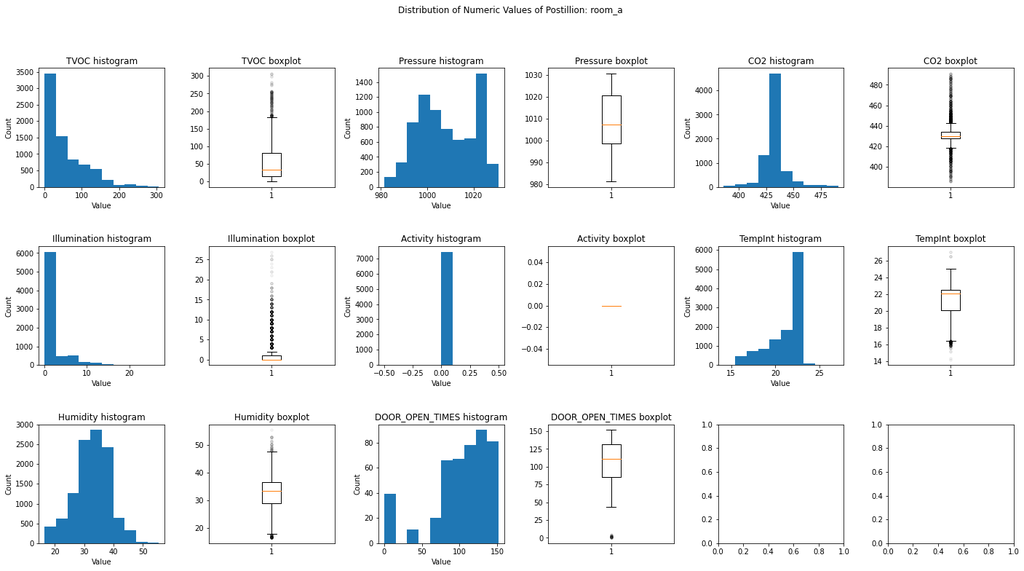

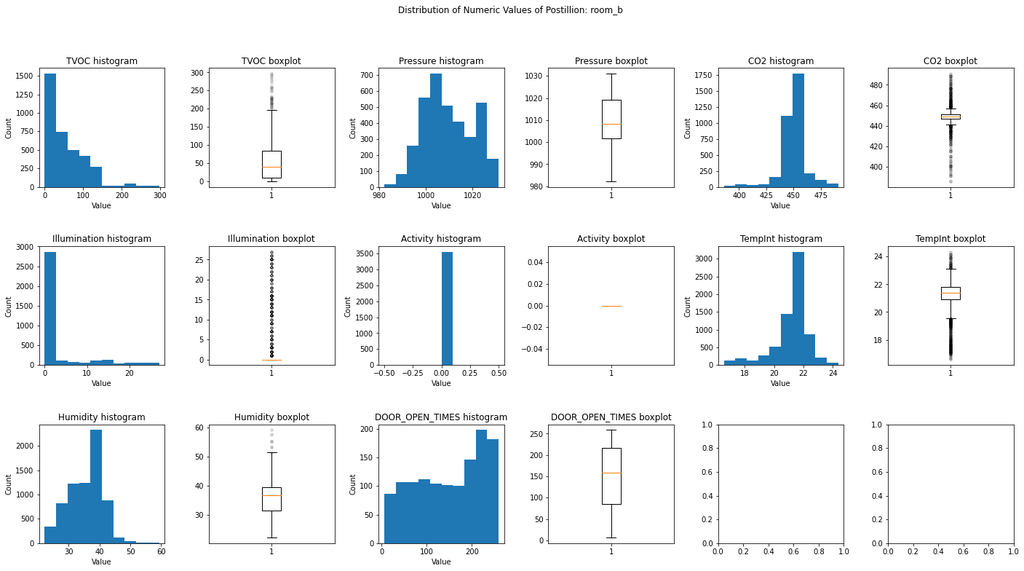

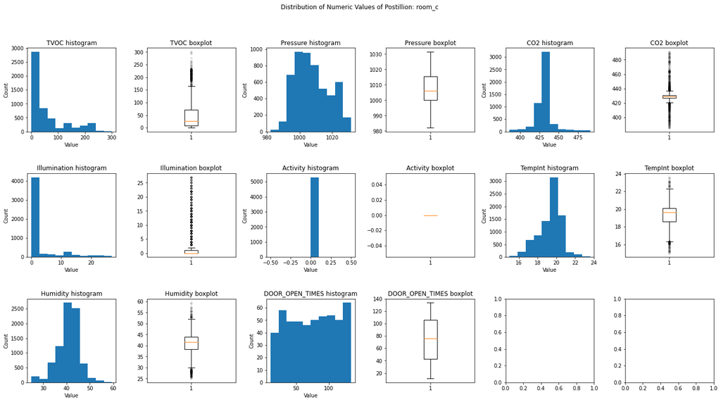

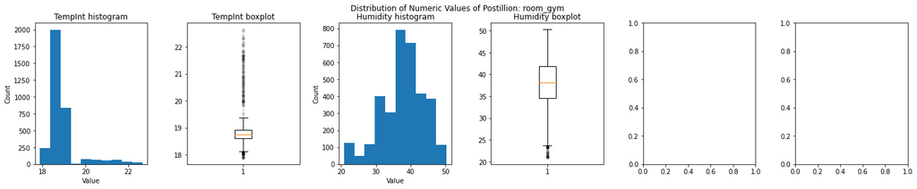

```python
subset = postillion_df.select_dtypes(np.number).copy()
subset['room'] = postillion_df['room']

rooms = subset['room'].unique()

for room in rooms:
    room_data = subset[subset['room'] == room]
    room_data = room_data.dropna(axis=1, how='all')
    columns = room_data.select_dtypes(np.number).columns.values
    p_axes = visualize_room(room_data, columns, f'Distribution of Numeric Values of Postillion: {room}', 'Value', 'Count')
```

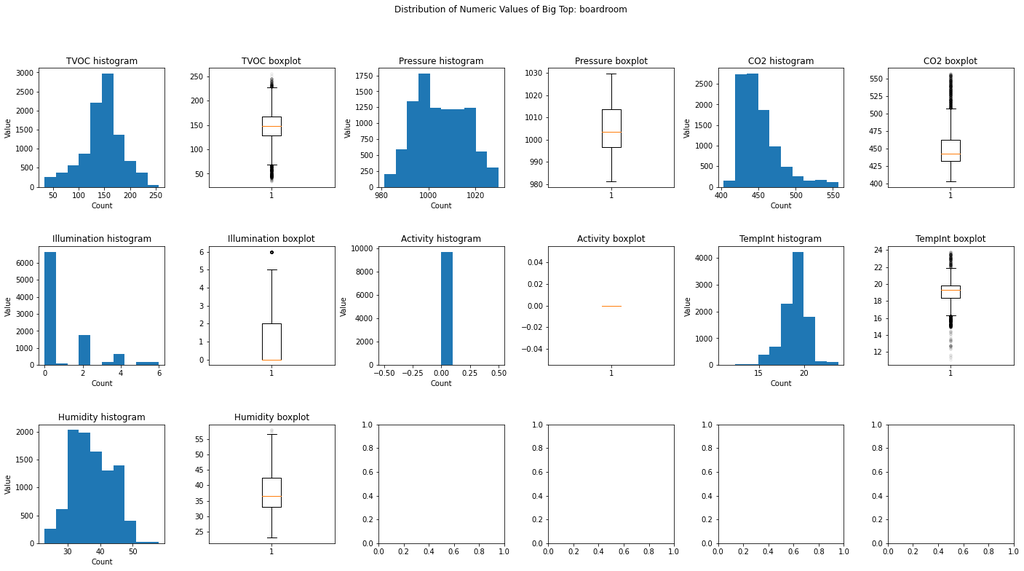

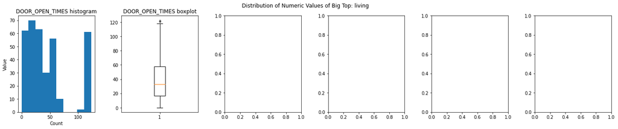

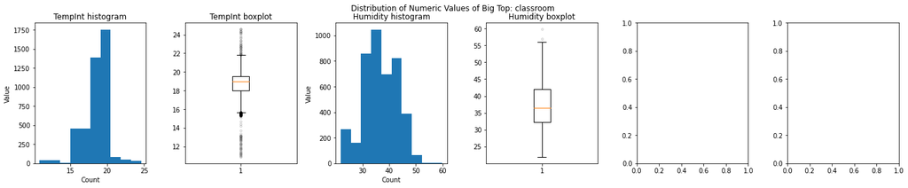

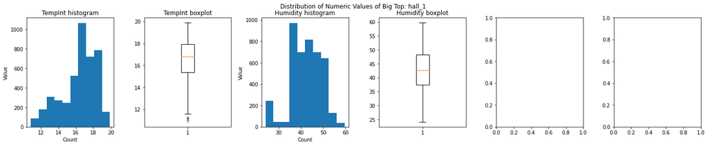

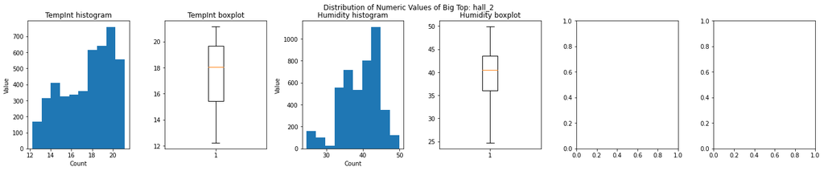

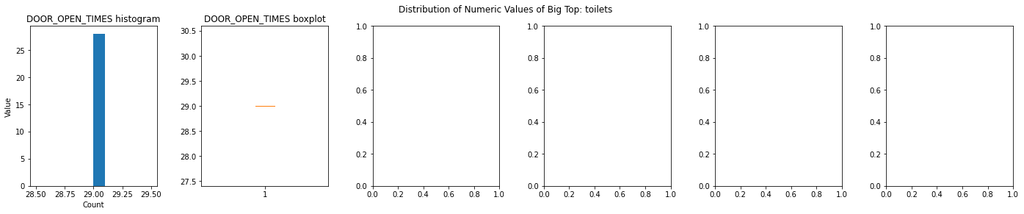

```python
subset = big_top_df.select_dtypes(np.number).copy()
subset['room'] = big_top_df['room']

rooms = subset['room'].unique()

for room in rooms:
    room_data = subset[subset['room'] == room]
    room_data = room_data.dropna(axis=1, how='all')

    # Do not visualize if there are less then 10 total datapoints for the current room
    if(len(room_data) > 10):
        columns = room_data.select_dtypes(np.number).columns.values
        bt_axes = visualize_room(room_data, columns, f'Distribution of Numeric Values of Big Top: {room}', 'Count', 'Value')
```

### 2.2 Categorical variables

```python
def visualize_door_status(dataframe, rooms):
    fig, axes = plt.subplots(1, len(rooms))
    fig.set_size_inches(len(rooms) * 4, len(rooms))
    fig.suptitle('Counts of "DOOR_OPEN_STATUS".')

    for index, room in enumerate(rooms):
        data = dataframe[dataframe['room'] == room]['DOOR_OPEN_STATUS'].value_counts()
        if len(data) > 0:
            ax = axes[index]
            data.plot(kind='bar', ax=ax)
            ax.set_title(room)

    plt.tight_layout()
```

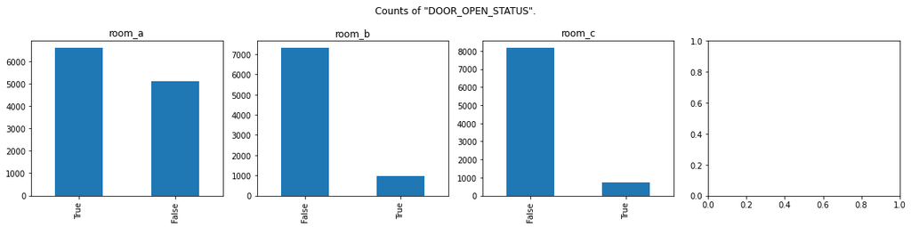

```python
# Visualize per location per room the door open status count
subset = postillion_df[['room', 'DOOR_OPEN_STATUS']]
rooms = subset['room'].unique()

visualize_door_status(subset, rooms)
```

### 2.3 Insights

The data contains large outliers. When using the IQR outlier removal method about 20% of the data is dropped. This might indicate that there are, or were, faulty measurements being made or that there are indeed many anomalies.

There is also a difference in which data is recorded for each room. The data reading pipeline results in a dataset that has data for the most important, all air quality and temperature, columns. This means that only data for rooms a, b and c for the Postillion hotel and the boardroom for the Big Top are available.

Before dropping the outliers the data was heavily skewed. This might cause inaccuracies in regression models. To prevent this normalization techniques might need to be applied.

## 3. Bi-variate analysis

### 3.1 Correlation coefficient heatmaps

```python
def draw_correlation_heatmap(data, ax):
    # Extract all numeric data from the current room from the subset. DOOR_OPEN_TIMES is not needed.
    data = data.select_dtypes(np.number)
    # Calculate correlation coefficients.
    corr = data.corr()
    # Calculate mask to hide duplicates in the matrix.
    mask = np.triu(corr)
    # Visualize
    sns.heatmap(corr, ax=ax, annot=True, square=True, vmin=-1, vmax=1, cmap='coolwarm', cbar_kws={'shrink': .65}, mask=mask)
    # Invert axis to increase readability.
    ax.invert_yaxis()
    ax.set_title(room)

    return (ax, corr)
```

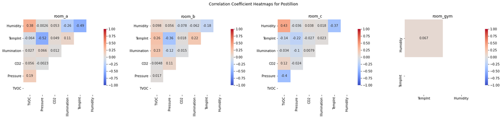

```python
# Loop through rooms, calculate correlation coefficients and visualize in heatmaps
subset = postillion_df.select_dtypes(np.number).copy()
subset['room'] = postillion_df['room']

rooms = subset['room'].unique()

fig, axes = plt.subplots(1, len(rooms))
fig.set_size_inches(len(rooms) * 6.66, 5)
fig.subplots_adjust(hspace=0.5, wspace=0.35)
fig.suptitle('Correlation Coefficient Heatmaps for Postillion')

corrs = []

for ax, room in zip(axes.flatten(), rooms):
    data = subset[subset['room'] == room]
    data = data.drop(['DOOR_OPEN_TIMES', 'Activity'], axis=1)
    data = data.dropna(axis=1, how='all')

    ax, corr = draw_correlation_heatmap(data, ax)
    # Save room and correlation matrix for later use in scatter plots.
    corrs.append((room, corr))
    ax.set_title(room)
```

```python
def scatter(dataframe, room, correlations, threshold=0.15, scale=1.5):
    # Square correlation matrix
    correlations = correlations ** 2

    # for each feature collect the most correlated. If any.
    for feature, row in correlations.iterrows():
        # Remove reference to the feature itself within the row
        row = row[row.index != feature]
        # Only keep the values that are above the threshold.
        row = row[row.values > threshold]
        # It is possible the feature is not strongly correlated to any other. In this case we cannot visualize it.
        if len(row) > 0:
            # Create a figure for the current feature and a subplot for each value its going to be compared to.
            fig, axes = plt.subplots(len(row), 1, squeeze=False)
            fig.set_size_inches(4, len(row) * 4)
            fig.suptitle(f'{room}:{feature}')
            fig.subplots_adjust(hspace=0.5, wspace=0.35)

            for ax, value, corr_value in zip(axes.flatten(), row.index, row.values):
                # Collect data and transform.
                x = df[feature]
                x = np.log(x)

                y = df[value]
                y = np.log(y)

                # visualize in scatter plot.
                ax.scatter(x, y, alpha=0.1)
                ax.set_title(f'{value} with a {round(math.sqrt(corr_value), 2)} correlation score.')
                ax.set_xlabel(f'{feature} (log)')
                ax.set_ylabel(f'{value} (log)')
```

```
Removed 4446 outliers.
```

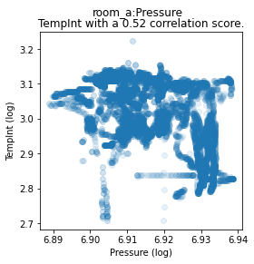

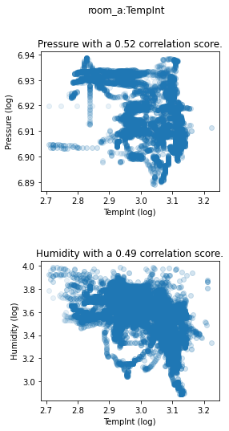

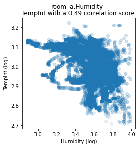

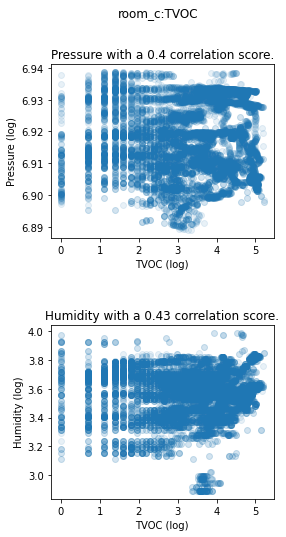

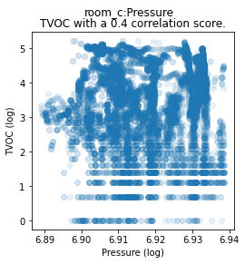

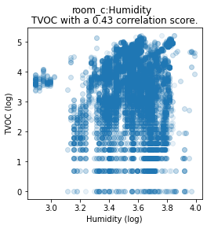

```python
# Scatterplots are sensitive to outliers. Extra outlier removal is required.
df = iqr_outlier_removal(postillion_df)

for room, correlations in corrs:
    scatter(df, room, correlations)
```

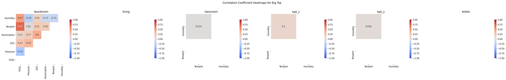

```python
# Loop through rooms, calculate correlation coefficients and visualize in heatmaps
subset = big_top_df.select_dtypes(np.number).copy()
subset['room'] = big_top_df['room']

rooms = subset['room'].unique()

fig, axes = plt.subplots(1, len(rooms))
fig.set_size_inches(len(rooms) * 6.66, 5)
fig.subplots_adjust(hspace=0.5, wspace=0.35)
fig.suptitle('Correlation Coefficient Heatmaps for Big Top')

corrs = []

for ax, room in zip(axes.flatten(), rooms):
    data = subset[subset['room'] == room]
    data = data.drop(['DOOR_OPEN_TIMES', 'Activity'], axis=1)
    data = data.dropna(axis=1, how='all')

    ax, corr = draw_correlation_heatmap(data, ax)
    corrs.append((room, corr))
    ax.set_title(room)
```

```
Removed 1790 outliers.
```

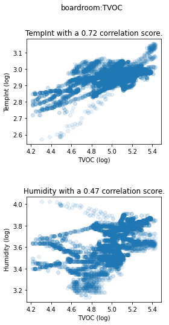

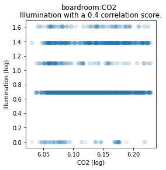

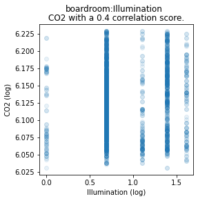

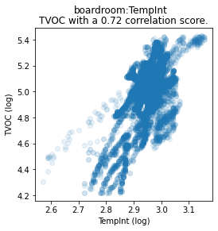

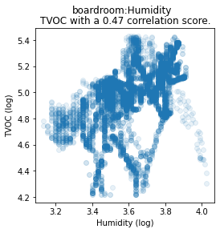

```python
df = iqr_outlier_removal(big_top_df)

for room, correlations in corrs:
    scatter(df, room, correlations)
```

### 3.2 Insights

When looking at the heatmaps and scatterplots we can conclude that there few strongly related features. The strength of the also differs per room, indicating that there might be other factors that needs to be considered.

The features of the dataset can be used to define the air quality of a room. It needs to be expanded with data that cause changes to these features.

## 4. Missing Value Treatment

During the preparation phase the event based data is converted to tabular data. This is done by joining the events based on timestamps. When there are no events within range this will result in NaN values, as can be seen below. During the model development a pipeline step could be added to impute the missing data.

```python
def calculate_percentage_of_missing(df):
    return round(df.isnull().sum() * 100 / len(df), 2)
```

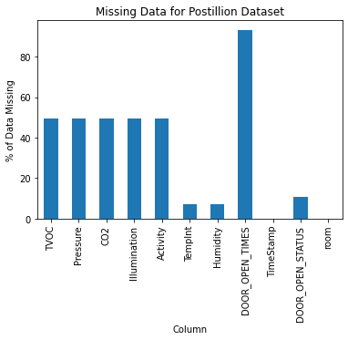

```python
missing = calculate_percentage_of_missing(postillion_df)
ax = missing.plot(kind='bar', title='Missing Data for Postillion Dataset')
ax.set_xlabel('Column')
ax.set_ylabel('% of Data Missing')
```

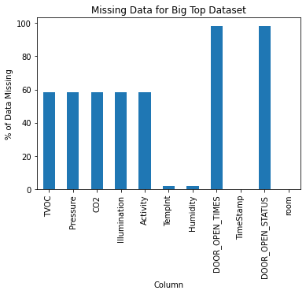

```python
missing = calculate_percentage_of_missing(big_top_df)
ax = missing.plot(kind='bar', title='Missing Data for Big Top Dataset')
ax.set_xlabel('Column')
ax.set_ylabel('% of Data Missing')
```

## 5. Outlier Treatment

for the outlier treatment see the 'iqr_outlier_removal' function. The current outlier removal method drops ~20% of the datapoints. If this is too much the quantiles can be tweaked to contain less data points.

## 6. Conclusion

This Exploratory Data Analysis was conducted to see how the data collected by the Twindle application is put together. The following observations have been made:

- The data contains large outliers.
- The same data is not collected for each room.
- The data is heavily skewed which might cause inaccuracies when used in regression algorithms.
- There is a lack of strongly correlated features.
- Some columns have large amounts of missing data; this needs to be fixed in the extraction pipeline, imputed or dropped.
- The outlier removal method deletes about ~20% of the data; quantiles could be tweaked to lower this amount.

Based on these observations the data requirements can be researched. There needs to be a single feature that indicates air quality, based on temperature, humidity, etc. Data that signal changes in the current features need to be added to the dataset. Together this can be used to develop a machine learning model that is able to predict the air quality.